# Project Report of Practical Machine Learning

by Jack Mok

## Introduction

This report is for Practical Machine Learning Course Project.

## Data Source

Training data : https://d396qusza40orc.cloudfront.net/predmachlearn/pml-training.csv

Testing data : https://d396qusza40orc.cloudfront.net/predmachlearn/pml-testing.csv

Source : http://groupware.les.inf.puc-rio.br/har

## Backgroud

- In this project, we will be to use data from accelerometers on the belt, forearm, arm, and dumbell of 6 participants. They were asked to perform barbell lifts correctly and incorrectly in 5 different ways. More information is available from the website here: http://groupware.les.inf.puc-rio.br/har (see the section on the Weight Lifting Exercise Dataset).

## Exploratory Analysis

### Dataset Overview

- This dataset is licensed under the Creative Commons license (CC BY-SA). Read more: http://groupware.les.inf.puc-rio.br/har#dataset#ixzz4LROCJIrX
- Six young health participants were asked to perform one set of 10 repetitions of the Unilateral Dumbbell Biceps Curl in five different fashions: exactly according to the specification (Class A), throwing the elbows to the front (Class B), lifting the dumbbell only halfway (Class C), lowering the dumbbell only halfway (Class D) and throwing the hips to the front (Class E).
- Read more: http://groupware.les.inf.puc-rio.br/har#ixzz4LRQBWXBv

### Data Loading and Cleaning

- The dimension of training set is 13737 rows x 160 variables.
- The dimension of test set is 5885 rows x 160 variables.
- After remove NA value (Threshold : 95% NA) and the following Unrelevant variables : X, ‘user_name’, ‘raw_timestamp_part_1’, ‘raw_timestamp_part_2’, ‘cvtd_timestamp’, ‘new_window’, ‘num_window’
- The dimension of training set is 13737 rows x 53 variables.
- The dimension of test set is 5885 rows x 53 variables.
- The dimension of test case set is 20 rows x 53 variables.

# Correlation Analysis

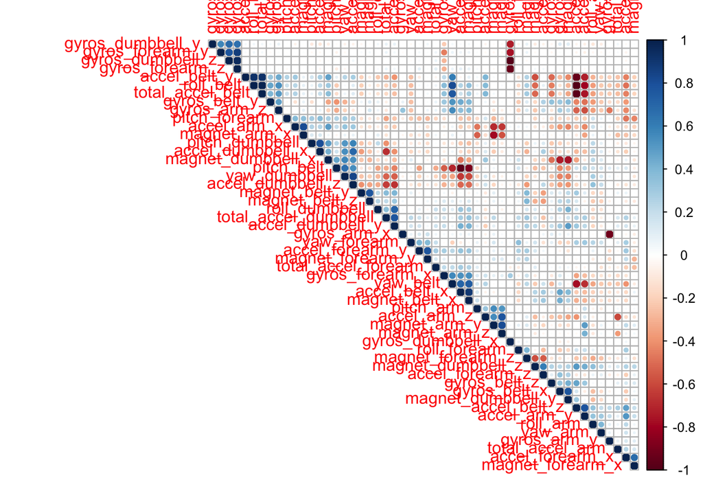

### Random Forest

```
## Confusion Matrix and Statistics
##
##           Reference
## Prediction    A    B    C    D    E
##          A 1674    8    0    0    0
##          B    0 1130    5    0    0
##          C    0    1 1021    4    0
##          D    0    0    0  959    1
##          E    0    0    0    1 1081
##
## Overall Statistics
##
##                Accuracy : 0.9966
##                  95% CI : (0.9948, 0.9979)
##     No Information Rate : 0.2845
##     P-Value [Acc > NIR] : < 2.2e-16
##
##                   Kappa : 0.9957
##  Mcnemar's Test P-Value : NA
##
## Statistics by Class:
##
##                      Class: A Class: B Class: C Class: D Class: E
## Sensitivity            1.0000   0.9921   0.9951   0.9948   0.9991
## Specificity            0.9981   0.9989   0.9990   0.9998   0.9998
## Pos Pred Value         0.9952   0.9956   0.9951   0.9990   0.9991
## Neg Pred Value         1.0000   0.9981   0.9990   0.9990   0.9998
## Prevalence             0.2845   0.1935   0.1743   0.1638   0.1839
## Detection Rate         0.2845   0.1920   0.1735   0.1630   0.1837
## Detection Prevalence   0.2858   0.1929   0.1743   0.1631   0.1839
## Balanced Accuracy      0.9991   0.9955   0.9970   0.9973   0.9994
```

### Decision Tree

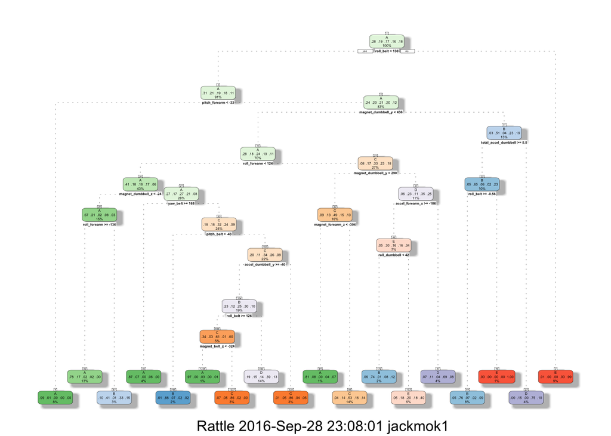

```
## Confusion Matrix and Statistics
##
##           Reference
## Prediction    A    B    C    D    E
##          A 1364  169   24   48   16
##          B   60  581   46   79   74
##          C   52  137  765  129  145
##          D  183  194  125  650  159
##          E   15   58   66   58  688
##
## Overall Statistics
##
##                Accuracy : 0.6879
##                  95% CI : (0.6758, 0.6997)
##     No Information Rate : 0.2845
##     P-Value [Acc > NIR] : < 2.2e-16
##
##                   Kappa : 0.6066
##  Mcnemar's Test P-Value : < 2.2e-16
##
## Statistics by Class:
##
##                      Class: A Class: B Class: C Class: D Class: E
## Sensitivity            0.8148  0.51010   0.7456   0.6743   0.6359
## Specificity            0.9390  0.94543   0.9047   0.8657   0.9590
## Pos Pred Value         0.8415  0.69167   0.6230   0.4958   0.7774
## Neg Pred Value         0.9273  0.88940   0.9440   0.9314   0.9212
## Prevalence             0.2845  0.19354   0.1743   0.1638   0.1839
## Detection Rate         0.2318  0.09873   0.1300   0.1105   0.1169
## Detection Prevalence   0.2754  0.14274   0.2087   0.2228   0.1504
## Balanced Accuracy      0.8769  0.72776   0.8252   0.7700   0.7974
```

### Model Evulation

- The Accuracy of Random Forest is 0.9966015.
- The Accuracy of Decision Tree is 0.6878505.
- Therefore, using Random forest is more accurate than using Decision Tree.

# Applying Selected Model to the test data

### Predict Results

```
##  1  2  3  4  5  6  7  8  9 10 11 12 13 14 15 16 17 18 19 20
##  B  A  B  A  A  E  D  B  A  A  B  C  B  A  E  E  A  B  B  B
## Levels: A B C D E
```